# Practical session: measures of genetic diversity and differentiation

Vitor C. Sousa

2019

# Objectives of this practical session

Summarize genetic diversity and differentiaion patterns  
1. What is the most and less diverse population?

- Compute expected heterozygosity $H_e$
- Compute observed heterozygosity $H_o$
- Estimate fixation index $F_{IS}$ (deviation from Hardy-Weinberg equilibrium)
2. What is the level of differentiation among populations?
- Compute pairwise $F_{ST}$ for pairs of samples

To discuss:

- what factors affect the genetic diversity of populations?
- what factors affect the genetic differentiation among populations?

## 1. Dataset: Human exome data from Henn et al. (2015) PNAS

The folder “/Henn_et_al_data” contains exome data from seven human populations (file: Hennetal_genotypeMatrix.geno). This is a sub-set of 10,000 SNPs of the data published in Henn et al. (2015) PNAS (http://www.pnas.org/content/113/4/E440.abstract). This data was kindly provided by Stephan Peischl (http://www.bioinformatics.unibe.ch/about_us/staff/dr_peischl_stephan/index_eng.html), and cannot be used outside the scope of this course.

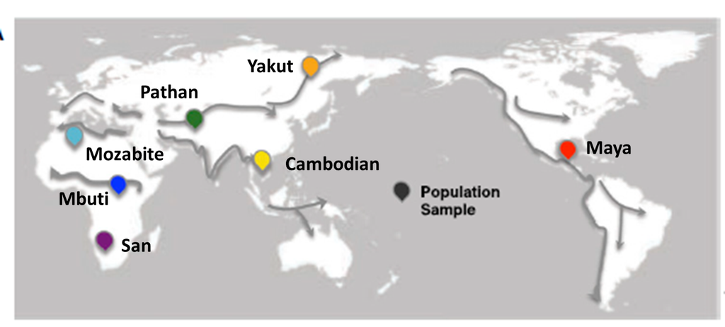

The seven human populations analysed are:  
- Namibian San (SAN, https://en.wikipedia.org/wiki/San_people);  
- Mbuti Pygmi from Democratic Republic of Congo (MBUTI, https://en.wikipedia.org/wiki/Mbuti_people);  
- Algerian Mozabite (MOZABITE, https://en.wikipedia.org/wiki/Mozabite_people);  
- Pakistani Pathan (PATHAN, https://en.wikipedia.org/wiki/Pathans_of_Punjab);  
- Cambodian (CAMBODIAN);  
- Siberian Yakut (YAKUT, https://en.wikipedia.org/wiki/Yakuts);  
- Mexican Mayan (MAYA, https://en.wikipedia.org/wiki/Maya_peoples)

> Exercise 1  
> Have a look at the file with the data (/Henn_et_al_data/Hennetal_genotypeMatrix.geno).  
> - What are the values reported?  
> - What are rows and columns?  
> - How many individuals?

This is a genotypic data matrix where each entry codes for the genotypes as 0 (homozygote for reference allele), 1 (heterozygote), 2 (homozygote for alternative allele). In this matrix each column corresponds to an individual, and each row corresponds to a site (position in the genome).

## 2. What is the most genetically diverse population?

### 2.1. Compute expected heterozygosity

We will now have a look at this file and compute the expected heterozygosity for each sample/population.

The expected heterozygosity is computed for each SNP as the probability of taking two sequences from the population that are different, i.e. taking two sequences with two different alleles. This can then be averaged across SNPs to obtain a measure of genetic diversity for a given sample. In a sample of $n_i$ sequences at a given site, the expected heterozygosity $H_e$ can be computed as the mean across $L$ sites:

$H_e = \frac{1}{L} \sum_{i=1}^{L} \frac{n_i}{n_i-1} 2 p_i (1-p_i)$

where $p_i$ is the frequency of one of the alleles at a particular site, and $(1-p_i)$ is the frequency of the alternative allele. NOTE: given that we have diploid individuals, each individual has two copies of a gene (one from the mother, one from the father), and hence the sample size is 2*nind.

> Exercise 2  
> Follow the R commands below to:  
> - read the genotype table  
> - get the matrix with the genotypes for each sample  
> - compute the mean expected heterozygosity for each population.  
> - compute the mean observed heterozygosity for each population.

Below you have a script to compute the heterozygosity for one sample. Compute the expected heterozygosity for all the other samples. For the ones who do not like challenges you can scroll down to see an example of a script to compute the expected heterozygosity for all pops.

```r
# set the working directory (NEVER FORGET THIS!!!)
setwd("PATH_TO_YOUR_WORKING_DIRECTORY")
```

```r
# load functions to compute the expected heterozygosity
source("utilfunctions.r")

# read the genotype matrix
geno <- as.matrix(read.table("./Henn_et_al_data/Hennetal_genotypeMatrix.geno", header=T, stringsAsFactors = F, na.strings = "NA"))
# check if we read genotype matrix correctly
#str(geno) # matrix with nsites rows and nind columns
# How many individuals? How many sites?

# get the label of the individuals
inds <- colnames(geno)

# Get the index of the individuals for San
# Note that the individual label starts with the population name
# Hence we can use the substr() function to get the substring with the population name
# from the individual label. Check the help of substr() to understand what is done below.
san_inds <- which(substr(inds, 1, 3)=="San")
```

Repeat this for the other populations. Here is a vector with the population labels. Every individual name in geno matrix starts with the population name.

```r
# vector with the population name
pop.names <- c("San","Mbuti","Mozabite","Pathan","Cambodian","Yakut","Maya")
```

The code below shows how you can compute the expected heterozygosity for all samples using lists and matrices as in the code below.

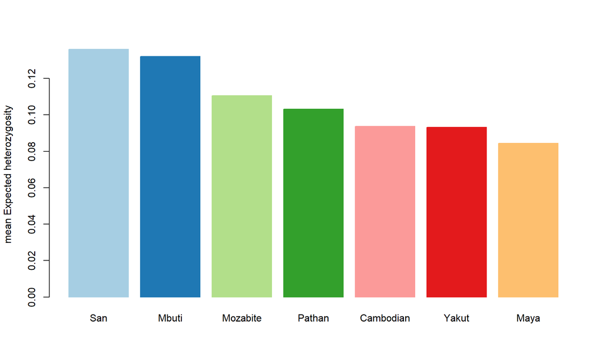

```r
# A way to get this for all populations
# go through each pop.name and get the index of individuals of each pop
sample_inds <- list() # list to save the index of individuals belonging to each pop
for(i in 1:length(pop.names)) {
  # apply the function to detect which individuals belong to each pop
  sample_inds[[i]] <- which(substr(inds, 1, nchar(pop.names[i]))==pop.names[i])
}
# check the result
#str(sample_inds)

# Get the expected heterozygosity for each sample
# initialize matrix to save heterozygosity for each SNP and for each pop
# het is a matrix with nsnps rows and npop columns
exp_het <- matrix(NA,nrow=nrow(geno), ncol=length(pop.names))
# go through each population
for(i in 1:length(pop.names)) {
  # compute the heterozygosity by looking at a subset of individuals from geno matrix
  exp_het[,i] <- apply(geno[,sample_inds[[i]]], 1, function(row) {ExpHet(row)})
}
# check the output
#str(exp_het)

# get the mean het for each pop
mean_exp_het <- colMeans(exp_het)

# Compare the het for each pop in a barplot
library(RColorBrewer) # this is a cool package with color palletes
#display.brewer.all(n=NULL, type="all", select=NULL, exact.n=TRUE, colorblindFriendly=TRUE)
# create a pallete with one color for each pop using a qualitative pallete
mycols <- brewer.pal("Paired", n=length(pop.names))
barplot(mean_exp_het, names.arg = pop.names, col=mycols, border=mycols, beside=T, ylab="mean Expected heterozygosity")
```

> CHECK you understand the code:  
> - What is saved in variable sample_inds?  
> - The sample_inds is a list. Why a list and not a vector or a matrix?  
> - How to access the elements of a list?  
> - What is saved in variable popinds?  
> - How can we use sample_inds to access elements of matrix geno?

> TO DISCUSS ABOUT GENOMICS  
> - What is the population with the higher expected heterozygosity?  
> - What is the population with the higher genetic diversity?  
> - What evolutionary processes could lead to these differences among populations?

### 2.2. Compute the observed heterozygosity for each sample

The observed heterozygosity is the actual proportion of heterozygote sites per individual. For a given population, the observed heterozygosity is the averaged across individuals.

> Exercise 3  
> Follow the script below to:  
> - Compute the observed heterozygosity for each individual  
> - Compute the mean observed heterozygosity for each sample

The script below gives you an example of how to compute the observed heterozygosity for one individual.

```r
# OBS_HET
# function to compute the observed heterozygosity for a given individual
# INPUT:
#   geno_ind : numeric vector of size nsites with the genotypes for a given individual, coded as:
#   0 (homozygote reference allele), 1 (heterozygote), 2 (homozygote alternative allele) or NA (missing data)
# OUTPUT:
#    obs_het : numeric value with the observed heterozygosity
obs_het <- function(geno_ind) {

  # get the number of sites that are heterozygotes
  # NOTE: need to perform the sum discarding missing data (use na.rm=T)
  het_sites <- sum(geno_ind==1, na.rm=T)
  # divide by the total number of sites
  # the function is.na() returns TRUE for sites with missing data
  # them, !is.na() returns TRUE for sites with data
  het_sites/sum(!is.na(geno_ind))
}
```

```r
# Get the observed heterozygosity for each individual
obs_het <- apply(geno, 2, function(col) {obs_het(col)})
# str(obs_het)

# obs_het is a matrix with nsnps rows and npop columns
mean_obs_het <- numeric(length(pop.names))
# go through each population
for(i in 1:length(pop.names)) {
  # compute the heterozygosity by looking at a subset of individuals from geno matrix
  mean_obs_het[i] <- mean(obs_het[sample_inds[[i]]])
}
# check the output
#str(mean_obs_het)
```

After computing the mean oberved heterozygosity for each population, you can compare it with the mean expected heterozygosity for each population.

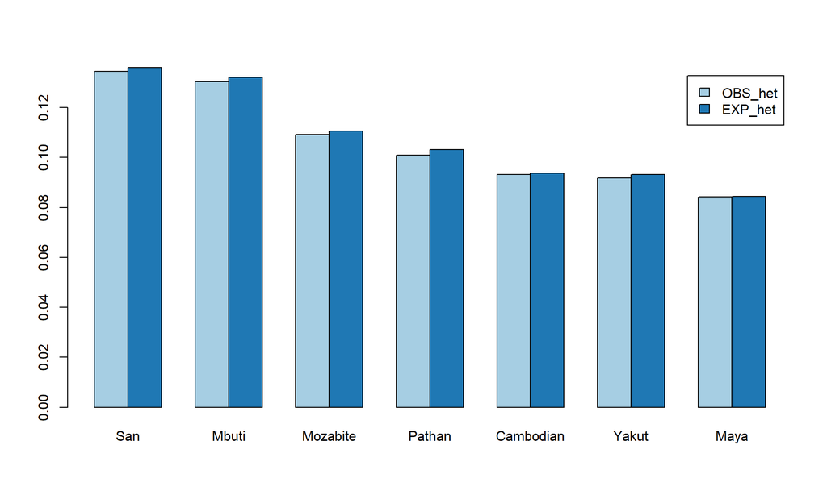

```r
# Plot the mean_obs_het and mean_exp_het
barplot(rbind(mean_obs_het,mean_exp_het), col=mycols[1:2], beside=T, names.arg = pop.names, legend.text = c("OBS_het","EXP_het"))
```

> TO DISCUSS  
> What is the best measure to quantify the genetic diversity of a population? The expected heterozygosity or the observed heterozygosity?  
> Is the observed and expected heterozygosities different?

### 2.3. Estimate the inbreeding coefficient ($F_{IS}$)

By comparing the observed heterozygosity with the expected heterozygosity, we can get an idea of whether the population from which we sampled the data is mating at random, i.e. according to Hardy-Weinberg equilibrium.

> QUESTION  
> What is expected under Hardy-Weinberg equilibrium about the relationship between observed and expected heterozygosities?

We can obtain an estimate for the inbreeding coefficient $F_{IS}$ for each individual based on the excess of homozygotes due to deviations from Hardy-Weinberg, as

$F_{IS}=1-\frac{H_o}{H_e}$

where $H_o$ is the mean observed heterozygosity across sites for a given individual, and $H_e$ is the mean expected heterozygosity of a given population.

> Exercise 4  
> Compute the estimator of $F_{IS}$ for each population using the code provided below.

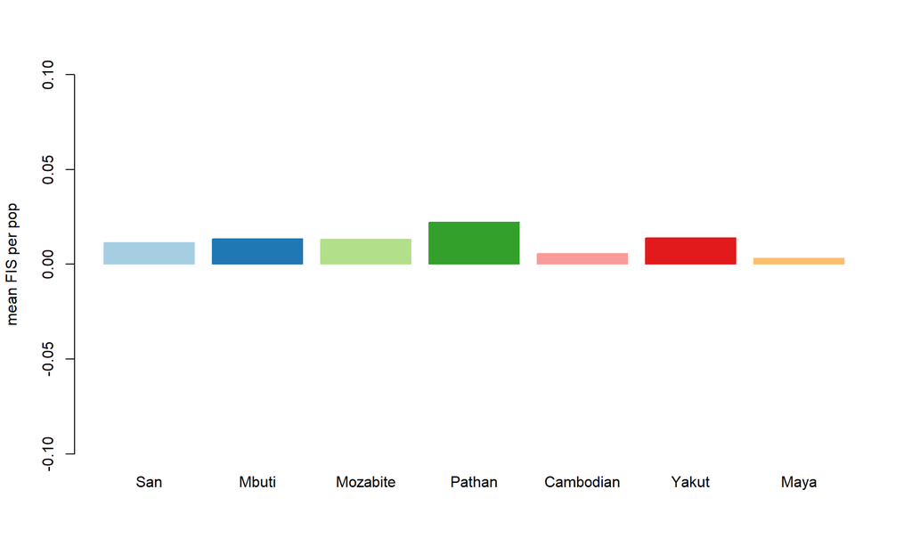

```r
# Estimate the inbreeding coefficient per population
fis <- 1-(mean_obs_het/mean_exp_het)

# Plot the FIS per sample
barplot(fis, names.arg = pop.names, col=mycols, border=mycols, beside=T, ylab="mean FIS per pop", ylim=c(-0.1,0.1))
```

> TO DISCUSS  
> - What are the range of values that FIS can take?  
> - Are the observed values low or high?

## 3. What is the level of differentiation among populations?

### 3.1. Estimate the pairwise $F_{ST}$ among all pairs of populations

The $F_{ST}$ index can be seen as a measure of population structure, and is a function of the allele frequencies within each sub-population, and the overall allele frequencies across all sub-populations.

There is also an important aspect to notice: $F_{ST}$ can be seen as parameters of models (for which we can obtain expression given some models), and also as estimators, when we try to infer these quantities based on real data. Real data always comes from a sample, and hence we need to find a way to deal with the variance (in a way the error) introduced by the sampling process.

For a pair of populations, one common estimator of $F_{ST}$ is based on comparing the probability of taking two different gene copies from within a sub-population, with the probability of taking two different gene copies from two different sub-populations. This is given by:

$\hat{F}_{ST}=1-\frac{\hat{H}_w}{\hat{H}_b}$

where $H_w$ is the mean expected heterozygosity of the two sub-populations (this is the mean **within**-populations, hence the subscript $w$) with the total expected heterozygosity based on the probability of taking two different gene copies from each population $H_b$ (this is the probability **between** populations). This is usually called the Hudson estimator (Hudson et al. 1992, Genetics http://www.genetics.org/content/132/2/583.long).

A more complete definition is given by.

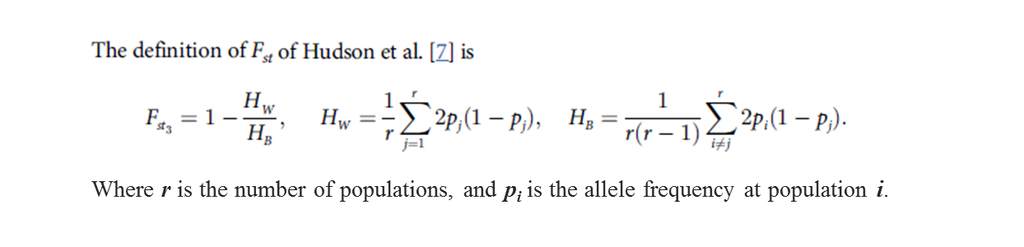

NOTE: there are many estimators of $F_{ST}$, and there is still research on finding the estimators with the best properties. That is, an estimator that will be close to the real population $F_{ST}$, which is an unknown parameter, except if we were able to sample and genotype all individuals at all sites. Usually estimators have a $\hat{}$ and parameters do not.

There are several estimators of $F_{ST}$, and this is still an area of research (For instance, see Chen et al. 2015 (http://journals.plos.org/plosone/article/metrics?id=10.1371/journal.pone.0135368) and Bhatia et al. 2013 (http://genome.cshlp.org/content/23/9/1514).

Due to its nice properties (bias, variance), the most widely used estimator is the one from Weir and Cockerham (1984) Evolution (https://www.jstor.org/stable/2408641?seq=1#page_scan_tab_contents). This is the estimator implemented in the R package SNPrelate.

But, for instance, a recent paper by Bhatia et al (2013) suggests using the Hudson estimator for pairwise comparisons.

> Exercise 5  
> - compute the pairwise $F_{ST}$ between all pairs of populations using the function implemented in package SNPrelate. Follow the code below.

Once you have a matrix with the pairwise $F_{ST}$ values, say in variable `pairwise_fst` you can plot the pairwise $F_{ST}$ using the image function and the function below.

```r
# PLOTFST
# function to plot the pairwise FST values
# INPUT:
#   fst : matrix with npop rows and npop columns with the pairwise FST
#   pnames : vector of size npop with the population labels
# OUTPUT
# plot with the pairwise FST
plotFst <- function(fst, pnames) {
  # layout defines that the plot area has two regions with different sizes
  layout(matrix(c(1,2), 1, 2, byrow = TRUE), widths=c(0.8,0.2))
  # use Rcolor brewer to define a color scale
  nclasses <- colorRampPalette(brewer.pal(8,"Oranges"))(15)
  # define the breakpoints
  breaksplot <- seq(0, max(fst, na.rm=T)*1.02,length.out = length(nclasses)+1)
  # plot the image
  image(1:nrow(fst), 1:nrow(fst), t(fst), breaks=breaksplot, xlab="", ylab="", col=nclasses, main="Pairwise FST", xaxt="n", yaxt="n")
  axis(1, at=c(1:nrow(fst)), labels=pnames)
  axis(2, at=c(1:nrow(fst)), labels=pnames)
  image.scale(t(fst), zlim=range(breaksplot), col = nclasses, breaks=breaksplot, horiz=FALSE, ylab="Pairwise FST", cex.lab=1.2, cex.axis=1.2, cex.main=1.2)
}
```

Now, lets use the SNPrelate package to compute the pairwise FST values using the Weir and Cockerham (1984) estimator. Compare these with your results.

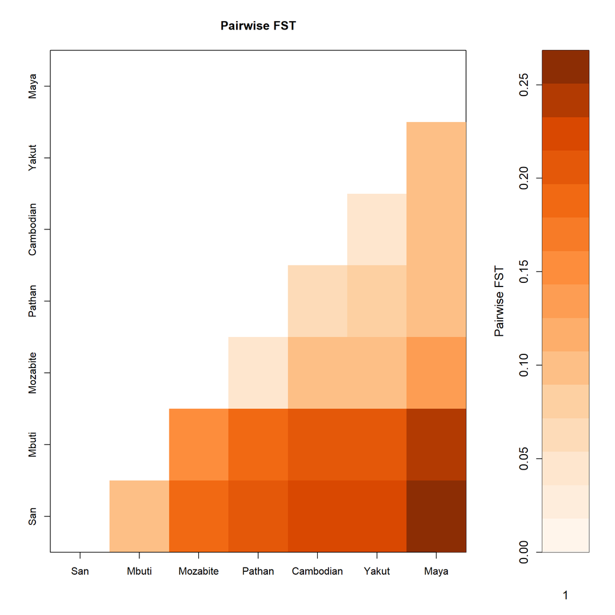

```r
# load the R package
library(SNPRelate)

# create tag
# this string will be added to the files saved by SNPrelate
filename_tag <- "HumanData"

# create a vector with the population corresponding to each individual
popinds <- names(geno) # initiliaze this with the individual names
for(i in 1:length(pop.names)) {
  # get pop.name label for individuals belonging to a given pop
  popinds[sample_inds[[i]]] <- pop.names[i]
}

# create input geno file for package
filename_geno <- paste(filename_tag,"_geno.gds",sep="")
# use the package function, giving as input:
# - genmatrix is the genotype matrix "geno"
# - sample.id is the name of individuals in variable "inds"
snpgdsCreateGeno(gds.fn=filename_geno, genmat=geno, snpfirstdim=TRUE, sample.id=inds)

# Open the GDS file that you just created
# this GDS file is the format used by SNPrelate
genofile <- snpgdsOpen(filename=filename_geno)

# Compute the pairwise FST using function snpgdsFst
pairfst_wc <- matrix(NA, ncol=length(pop.names), nrow=length(pop.names))
# go through each pair of populations
for(i in 1:(length(pop.names)-1)) {
  for(j in (i+1):length(pop.names)) {
    # select individuals from the two populations
    keepfst <- popinds==pop.names[i] | popinds==pop.names[j]
    # call function snpgdsFst to compute FST using as method W&C84
    pairfst_wc[i,j] <- snpgdsFst(genofile, sample.id=inds[keepfst], population=as.factor(popinds[keepfst]),method="W&C84")$Fst
  }
}
# Close the GDS file
snpgdsClose(genofile)

# use the function to make the plot
plotFst(pairfst_wc, pop.names)
```

> DISCUSSION  
> What are the populations with the higher genetic differentiation?  
> What demographic events can lead to this differentiation?  
> What are the populations with higher gene flow levels?  
> What are the populations that diverged more recently?  
> How to test if the $F_{ST}$ values are significant? What would be the null hypothesis?